# Project Python Foundations: FoodHub Data Analysis

**Marks: 60**

### Context

The number of restaurants in New York is increasing day by day. Lots of students and busy professionals rely on those restaurants due to their hectic lifestyles. Online food delivery service is a great option for them. It provides them with good food from their favorite restaurants. A food aggregator company FoodHub offers access to multiple restaurants through a single smartphone app.

The app allows the restaurants to receive a direct online order from a customer. The app assigns a delivery person from the company to pick up the order after it is confirmed by the restaurant. The delivery person then uses the map to reach the restaurant and waits for the food package. Once the food package is handed over to the delivery person, he/she confirms the pick-up in the app and travels to the customer's location to deliver the food. The delivery person confirms the drop-off in the app after delivering the food package to the customer. The customer can rate the order in the app. The food aggregator earns money by collecting a fixed margin of the delivery order from the restaurants.

### Objective

The food aggregator company has stored the data of the different orders made by the registered customers in their online portal. They want to analyze the data to get a fair idea about the demand of different restaurants which will help them in enhancing their customer experience. Suppose you are hired as a Data Scientist in this company and the Data Science team has shared some of the key questions that need to be answered. Perform the data analysis to find answers to these questions that will help the company to improve the business.

### Data Description

The data contains the different data related to a food order. The detailed data dictionary is given below.

### Data Dictionary

- order_id: Unique ID of the order
- customer_id: ID of the customer who ordered the food
- restaurant_name: Name of the restaurant
- cuisine_type: Cuisine ordered by the customer
- cost_of_the_order: Cost of the order
- day_of_the_week: Indicates whether the order is placed on a weekday or weekend (The weekday is from Monday to Friday and the weekend is Saturday and Sunday)
- rating: Rating given by the customer out of 5
- food_preparation_time: Time (in minutes) taken by the restaurant to prepare the food. This is calculated by taking the difference between the timestamps of the restaurant's order confirmation and the delivery person's pick-up confirmation.
- delivery_time: Time (in minutes) taken by the delivery person to deliver the food package. This is calculated by taking the difference between the timestamps of the delivery person's pick-up confirmation and drop-off information

### Let us start by importing the required libraries

```python
# import libraries for data manipulation
import numpy as np
import pandas as pd

# import libraries for data visualization
import matplotlib.pyplot as plt
import seaborn as sns
```

### Understanding the structure of the data

```python
from google.colab import drive, files
drive.mount('/content/drive')
```

```python
# read the data
df = pd.read_csv('foodhub_order.csv')
# returns the first 5 rows
df.head()
```

|  | order_id | customer_id | restaurant_name | cuisine_type | cost_of_the_order | day_of_the_week | rating | food_preparation_time | delivery_time |
| --- | --- | --- | --- | --- | --- | --- | --- | --- | --- |
| 0 | 1477147 | 337525 | Hangawi | Korean | 30.75 | Weekend | Not given | 25 | 20 |
| 1 | 1477685 | 358141 | Blue Ribbon Sushi Izakaya | Japanese | 12.08 | Weekend | Not given | 25 | 23 |
| 2 | 1477070 | 66393 | Cafe Habana | Mexican | 12.23 | Weekday | 5 | 23 | 28 |
| 3 | 1477334 | 106968 | Blue Ribbon Fried Chicken | American | 29.20 | Weekend | 3 | 25 | 15 |
| 4 | 1478249 | 76942 | Dirty Bird to Go | American | 11.59 | Weekday | 4 | 25 | 24 |

#### Observations:

The DataFrame has 9 columns as mentioned in the Data Dictionary. Data in each row corresponds to the order placed by a customer.

### **Question 1:** How many rows and columns are present in the data? [0.5 mark]

```python
df
```

|  | order_id | customer_id | restaurant_name | cuisine_type | cost_of_the_order | day_of_the_week | rating | food_preparation_time | delivery_time |
| --- | --- | --- | --- | --- | --- | --- | --- | --- | --- |
| 0 | 1477147 | 337525 | Hangawi | Korean | 30.75 | Weekend | Not given | 25 | 20 |
| 1 | 1477685 | 358141 | Blue Ribbon Sushi Izakaya | Japanese | 12.08 | Weekend | Not given | 25 | 23 |
| 2 | 1477070 | 66393 | Cafe Habana | Mexican | 12.23 | Weekday | 5 | 23 | 28 |
| 3 | 1477334 | 106968 | Blue Ribbon Fried Chicken | American | 29.20 | Weekend | 3 | 25 | 15 |
| 4 | 1478249 | 76942 | Dirty Bird to Go | American | 11.59 | Weekday | 4 | 25 | 24 |
| ... | ... | ... | ... | ... | ... | ... | ... | ... | ... |
| 1893 | 1476701 | 292602 | Chipotle Mexican Grill $1.99 Delivery | Mexican | 22.31 | Weekend | 5 | 31 | 17 |
| 1894 | 1477421 | 397537 | The Smile | American | 12.18 | Weekend | 5 | 31 | 19 |
| 1895 | 1477819 | 35309 | Blue Ribbon Sushi | Japanese | 25.22 | Weekday | Not given | 31 | 24 |
| 1896 | 1477513 | 64151 | Jack's Wife Freda | Mediterranean | 12.18 | Weekday | 5 | 23 | 31 |
| 1897 | 1478056 | 120353 | Blue Ribbon Sushi | Japanese | 19.45 | Weekend | Not given | 28 | 24 |

1898 rows × 9 columns

#### Observations:

There are **1898 rows** and **9 columns** in the data.

### **Question 2:** What are the datatypes of the different columns in the dataset? (The info() function can be used) [0.5 mark]

```python
# Use info() to print a concise summary of the DataFrame
df.info()
```

```
<class 'pandas.core.frame.DataFrame'>
RangeIndex: 1898 entries, 0 to 1897
Data columns (total 9 columns):
 #   Column                 Non-Null Count  Dtype
---  ------                 --------------  -----
 0   order_id               1898 non-null   int64
 1   customer_id            1898 non-null   int64
 2   restaurant_name        1898 non-null   object
 3   cuisine_type           1898 non-null   object
 4   cost_of_the_order      1898 non-null   float64
 5   day_of_the_week        1898 non-null   object
 6   rating                 1898 non-null   object
 7   food_preparation_time  1898 non-null   int64
 8   delivery_time          1898 non-null   int64
dtypes: float64(1), int64(4), object(4)
memory usage: 133.6+ KB
```

#### Observations:

There are 3 different datatypes in the dataset, including **float64**, **int64** as well as **object**. The datatypes of each column are detailed below.

- float64: 'cost_of_the_order'
- int64: 'order_id', 'customer_id', food_preparation_time', 'delivery_time'
- object: 'restaurant_name', 'cuisine_type', 'day_of_the_week', 'rating'

### **Question 3:** Are there any missing values in the data? If yes, treat them using an appropriate method. [1 mark]

```python
missing_values_count = df.isnull().sum()

if missing_values_count.sum() == 0:
    print("There are no missing values in the DataFrame.")
else:
    print("There are missing values in the following columns:")
    print(missing_values_count[missing_values_count > 0])
```

```
There are no missing values in the DataFrame.
```

#### Observations:

There are **no missing values** in the DataFrame. However, for the 'rating' column, it contains 'Not given' values, which represents that no rating had been left by the customers and the missing values had already been returned as 'Not given' in the dataset.

### **Question 4:** Check the statistical summary of the data. What is the minimum, average, and maximum time it takes for food to be prepared once an order is placed? [2 marks]

```python
summary = df['food_preparation_time'].describe()
print(summary[['min', 'mean', 'max']])
```

```
min     20.00000
mean    27.37197
max     35.00000
Name: food_preparation_time, dtype: float64
```

#### Observations:

The statistical summary of food preparation time:

- minimum: 20.00 minutes
- average: 27.37 minutes
- maximun: 35.00 minutes

### **Question 5:** How many orders are not rated? [1 mark]

```python
num_not_rated = df['rating'].value_counts()['Not given']
print(f"There are {num_not_rated} orders that are not rated.")
```

```
There are 736 orders that are not rated.
```

#### Observations:

There are **736** orders that are not rated.

### Exploratory Data Analysis (EDA)

### **Question 6:** Explore all the variables and provide observations on their distributions. (Generally, histograms, boxplots, countplots, etc. are used for univariate exploration.) [9 marks]

Observations on **OrderID**

```python
df['order_id'].nunique()
```

```
1898
```

The dataset contains data from 1898 orders.

Observations on **CustomerID**

```python
df['customer_id'].nunique()
```

```
1200
```

The dataset contains data from 1200 customers.

Observations On **Restaurant Name**

```python
df['restaurant_name'].nunique()
```

```
178
```

The dataset contains data from 178 restaurants.

Observations on **Cuisine Type**

```python
df['cuisine_type'].describe().T
```

```
count         1898
unique          14
top       American
freq           584
Name: cuisine_type, dtype: object
```

Out of the 14 different cuisine types offered by the 178 restaurants in the dataset, the most popular cuisine type is American cuisine, with a total of 584 orders out of the 1898 orders recorded.

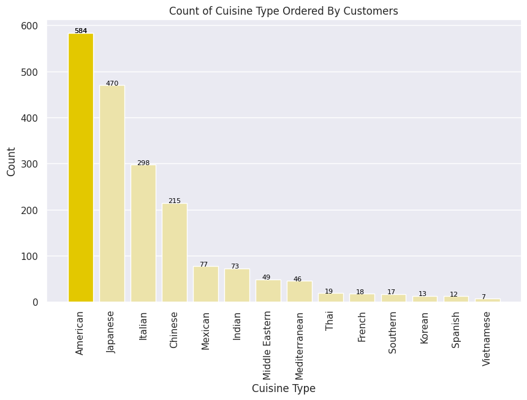

```python
# Get the most frequent cuisine type
most_frequent = df['cuisine_type'].value_counts().index[0]

# Plot the count of cuisine types
plt.figure(figsize=(10,6))
ax = sns.countplot(x='cuisine_type', data=df, order=df['cuisine_type'].value_counts().index, color='#f7eb9f')

# Highlight the most frequent cuisine type
plt.bar(most_frequent, df['cuisine_type'].value_counts()[most_frequent], color='#e3c800')

# Add value labels to each bar
for i in ax.patches:
    ax.text(i.get_x() + 0.2, i.get_height() + 0.2, str(round(i.get_height())), fontsize=8, color='black')

plt.xticks(rotation=90)
plt.xlabel('Cuisine Type')
plt.ylabel('Count')
plt.title('Count of Cuisine Type Ordered By Customers')
plt.show()
```

- The plot above displays the order amounts for each of the 14 cuisine types offered by the 178 restaurants in the dataset. It is clear from the plot that American cuisine is the most popular, followed by Japanese and Italian cuisine.
- Thai, French, Southern, Korean, Spanish, and Vietnamese cuisine are among the least frequently ordered items.

```python
# Get the value counts of all cuisine types
cuisine_counts = df['cuisine_type'].value_counts()

# Calculate the total count of all cuisines
total_count = cuisine_counts.sum()

# Calculate the ratio of the top 2 cuisines
top_2_counts = cuisine_counts[:2].sum()
top_2_ratio = top_2_counts / total_count

print(f'Top 2 cuisine ratio: {top_2_ratio:.2%}')
```

```
Top 2 cuisine ratio: 55.53%
```

- 55.53% of the orders are for **American and Japanese cuisine**, making them the most popular choices.

Observations on **Cost of Order**

```python
from scipy.stats import skew

# Calculate the skewness of the 'cost_of_the_order' variable
skewness = skew(df['cost_of_the_order'])

# Print the skewness
print('Skewness:', skewness)
```

```
Skewness: 0.6212555215510865
```

The skewness value of 0.6212555215510865 is positive, which means that the distribution of **the variable is slightly skewed to the right**. To further investigate the distribution, we will also look at other descriptive statistics such as mean, median, and standard deviation, as well as plot histograms or density plots to visually inspect the shape of the distribution.

```python
# calculate the mean
mean_cost = df['cost_of_the_order'].mean()
print(f"Mean Cost of the Order: {mean_cost:.2f}")

# calculate the median
median_cost = df['cost_of_the_order'].median()
print(f"Median Cost of the Order: {median_cost:.2f}")

# calculate the standard deviation
std_cost = df['cost_of_the_order'].std()
print(f"Standard Deviation of Cost of the Order: {std_cost:.2f}")
```

```
Mean Cost of the Order: 16.50
Median Cost of the Order: 14.14
Standard Deviation of Cost of the Order: 7.48
```

The mean cost of the order is 16.50 dollars, which means that on average, the customers spend 16.50 dollars per order.

The median cost of the order is 14.14 dollars, which is the value that separates the lower 50% of the data from the upper 50% of the data. Since the median is less than the mean, this suggests that the distribution of the 'cost_of_order' column is a bit **right-skewed**, with some higher cost orders that pull the mean up.

The standard deviation of the 'cost_of_order' column is 7.48 dollars, which means that the data is spread out around the mean by an average of 7.48 dollars. This gives an indication of the amount of variability in the data.

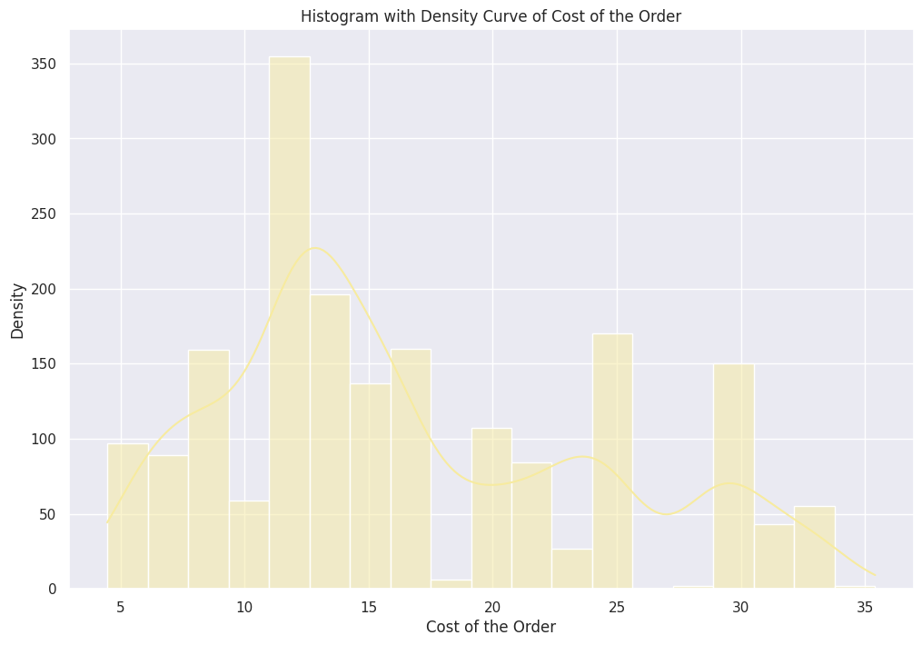

```python
# plot the histogram with density curve
sns.histplot(df['cost_of_the_order'], color='#f7eb9f', kde=True)

# set the title and axis labels
plt.title('Histogram with Density Curve of Cost of the Order')
plt.xlabel('Cost of the Order')
plt.ylabel('Density')

# show the plot
plt.show()
```

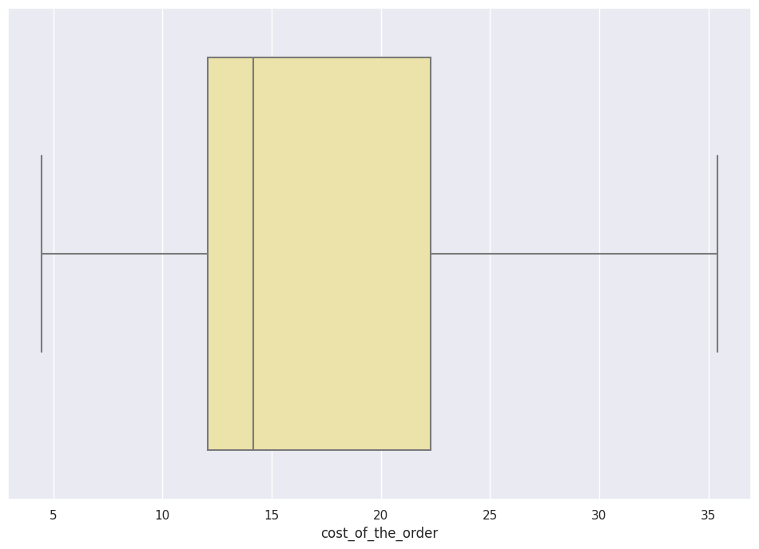

```python
sns.boxplot(data=df,x='cost_of_the_order', color= '#f7eb9f')
plt.show()
```

From the above plots, we can see that:

- Most of the data is concentrated within the range of 13 - 23, which means most of the orders cost $13 - $23.
- The distribution is skewed towards right.
- There is no outlier present in this column.
- The median is nearly 14.

Observations on **Day of the week**

```python
df['day_of_the_week'].value_counts()
```

```
Weekend    1351
Weekday     547
Name: day_of_the_week, dtype: int64
```

There are only 2 values, 'Weekend' and 'Weekday' in the day_of_the_week column.

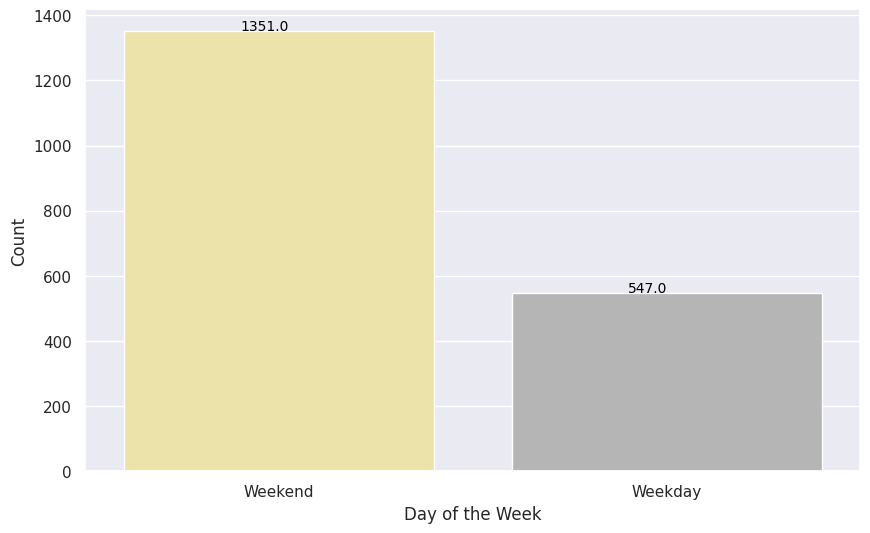

```python
# Compute frequency counts for each category in the 'day_of_the_week' column
counts = df['day_of_the_week'].value_counts()

# Determine the category with the most counts
most_frequent = counts.idxmax()

# Define a custom color palette
palette = ['#b5b5b5'] * len(counts)
palette[counts.index.get_loc(most_frequent)] = '#f7eb9f'

# Create the count plot with custom colors
plt.figure(figsize=(10,6))
ax = sns.countplot(x='day_of_the_week', data=df, palette=palette)

# Add value labels to each bar
for i in ax.patches:
    ax.text(i.get_x() + 0.3, i.get_height() + 2, str(i.get_height()), fontsize=10, color='black')

plt.xlabel('Day of the Week')
plt.ylabel('Count')
plt.show()
```

From the count plot above, we can see that:

- Weekends are the most popular time for orders, with more than twice as many orders as weekdays.

Observations on **Ratings**:

```python
df['rating'].value_counts()
```

```
Not given    736
5            588
4            386
3            188
Name: rating, dtype: int64
```

Based on the information provided in the data dictionary and the dataset itself, the 'rating' column represents the rating given by customers out of 5. It appears that only the values 3, 4, and 5 are present in the dataset, with no values between 0 and 2.

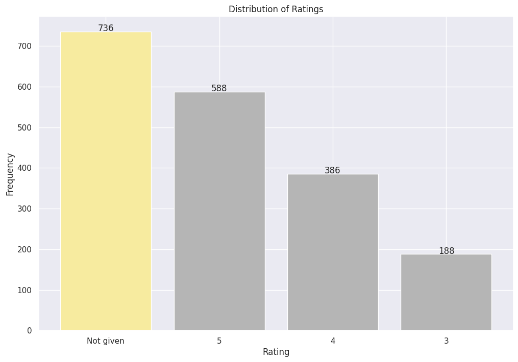

```python
# Compute frequency counts for each category in the 'rating' column
counts = df['rating'].value_counts()

# Determine the category with the most counts
most_frequent = counts.idxmax()

# Create a list of colors to use for each bar
colors = ['#b5b5b5'] * len(counts)
colors[counts.index.get_loc(most_frequent)] = '#f7eb9f'

# Create the bar chart with custom colors
plt.bar(counts.index, counts.values, color=colors)

# Add labels and title
plt.xlabel('Rating')
plt.ylabel('Frequency')
plt.title('Distribution of Ratings')

# Add value to each bar
for i, v in enumerate(counts.values):
    plt.text(i, v+1, str(v), ha='center')

# Show the plot
plt.show()
```

Observations on **Food Preparation Time**

```python
df['food_preparation_time'].describe().T
```

```
count    1898.000000
mean       27.371970
std         4.632481
min        20.000000
25%        23.000000
50%        27.000000
75%        31.000000
max        35.000000
Name: food_preparation_time, dtype: float64
```

From the information above, the mean (27.37) and median (27.00) are very close, it generally indicates that the distribution of the data is symmetric or roughly symmetric. In other words, the data points are evenly distributed around the central tendency. We will plot below to identify it.

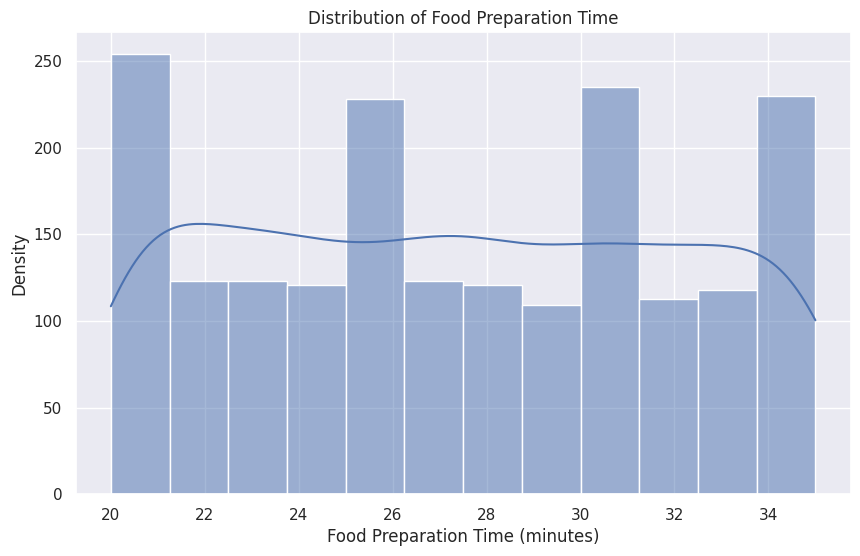

```python
plt.figure(figsize=(10,6))
sns.histplot(data= df, x= "food_preparation_time", kde= True)
plt.xlabel('Food Preparation Time (minutes)')
plt.ylabel('Density')
plt.title('Distribution of Food Preparation Time')
plt.show()
```

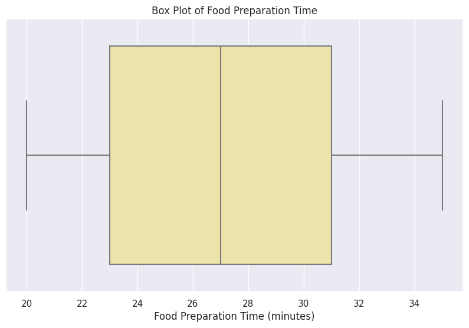

```python
plt.figure(figsize=(10,6))
sns.boxplot(x=df['food_preparation_time'], color= '#f7eb9f')
plt.xlabel('Food Preparation Time (minutes)')
plt.title('Box Plot of Food Preparation Time')
plt.show()
```

Observations on **Delivery Time**

```python
df['delivery_time'].describe().T
```

```
count    1898.000000
mean       24.161749
std         4.972637
min        15.000000
25%        20.000000
50%        25.000000
75%        28.000000
max        33.000000
Name: delivery_time, dtype: float64
```

```python
from scipy.stats import skew

# Calculate the skewness of the 'delivery_time' variable
skewness = skew(df['delivery_time'])

# Print the skewness
print('Skewness:', skewness)
```

```
Skewness: -0.23634932811816917
```

The skewness of -0.2363 suggests that the distribution of the data is **slightly negatively skewed**. Since the absolute value of the skewness is less than 1, the distribution is considered to be approximately symmetric. Therefore, the slight negative skewness of -0.2363 may not have a major impact on the analysis, and the usual assumptions of normality may still be valid. In addition, we can plot a histogram to visualise the skewness.

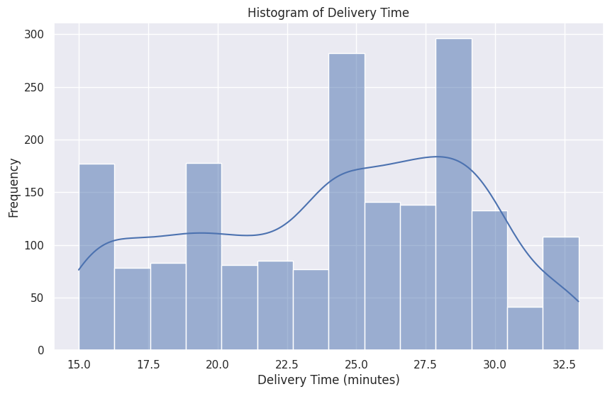

```python
plt.figure(figsize=(10,6))
sns.histplot(data= df, x= "delivery_time", kde= True)
plt.xlabel('Delivery Time (minutes)')
plt.ylabel('Frequency')
plt.title('Histogram of Delivery Time')
plt.show()
```

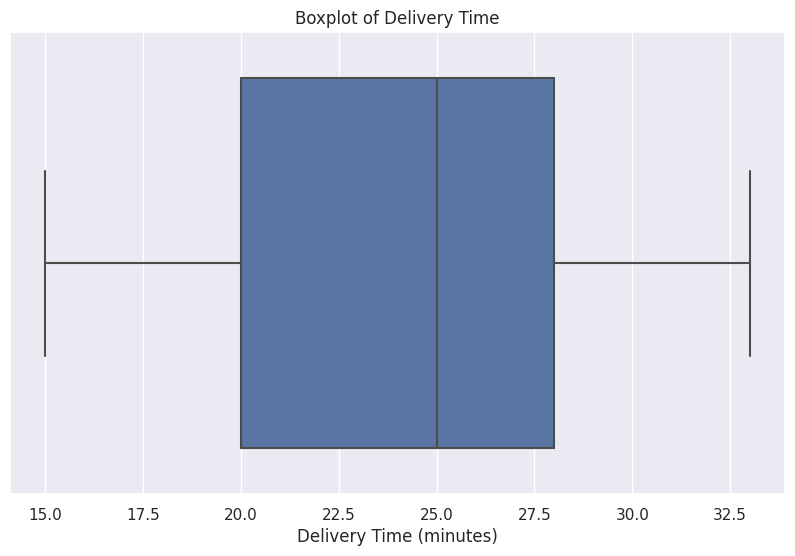

```python
plt.figure(figsize=(10,6))
sns.boxplot(data=df, x='delivery_time')
plt.xlabel('Delivery Time (minutes)')
plt.title('Boxplot of Delivery Time')
plt.show()
```

From the histogram, we can see that:

- The tail of the distribution is longer on the left side and the majority of the data points are clustered on the right side of the distribution.
- Most orders' delivery time is in 24-31 minutes.
- There is no outliers in this column.

### **Question 7**: Which are the top 5 restaurants in terms of the number of orders received? [1 mark]

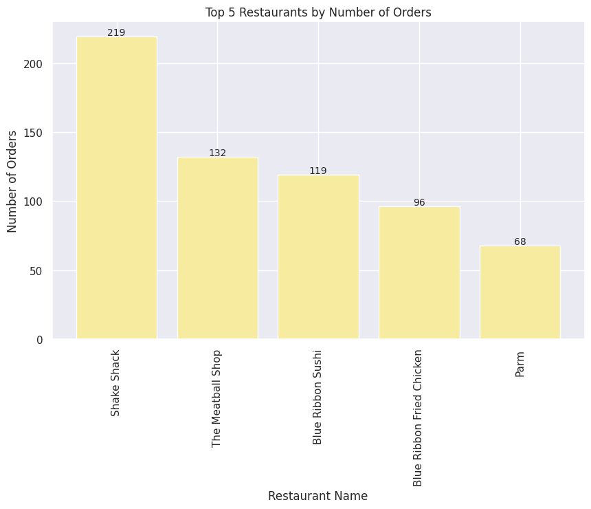

```python
# Group the orders by restaurant and count the number of orders for each restaurant
restaurant_orders = df.groupby('restaurant_name')['order_id'].count()

# Sort the restaurants in descending order of number of orders and get the top 5
top_restaurants = restaurant_orders.sort_values(ascending=False).head(5)

# Plot the top 5 restaurants
plt.figure(figsize=(10,6))
plt.bar(top_restaurants.index, top_restaurants.values, color= '#f7eb9f')
plt.xlabel('Restaurant Name')
plt.xticks(rotation=90)
plt.ylabel('Number of Orders')
plt.title('Top 5 Restaurants by Number of Orders')

# Add value labels to each bar
for i, v in enumerate(top_restaurants.values):
    plt.text(i, v+1, str(v), ha='center', fontsize=10)

plt.show()
```

#### Observations:

In terms of number of orders received, the top 5 restaurants are:

1<sup>st</sup> : Shake Shack (219 orders)

2<sup>nd</sup> : The Meatball Shop (132 orders)

3<sup>rd</sup> : Blue Ribbon Sushi (119 orders)

4<sup>th</sup> : Blue Ribbon Fried Chicken (96 orders)

5<sup>th</sup> : Parm (68 orders)

### **Question 8**: Which is the most popular cuisine on weekends? [1 mark]

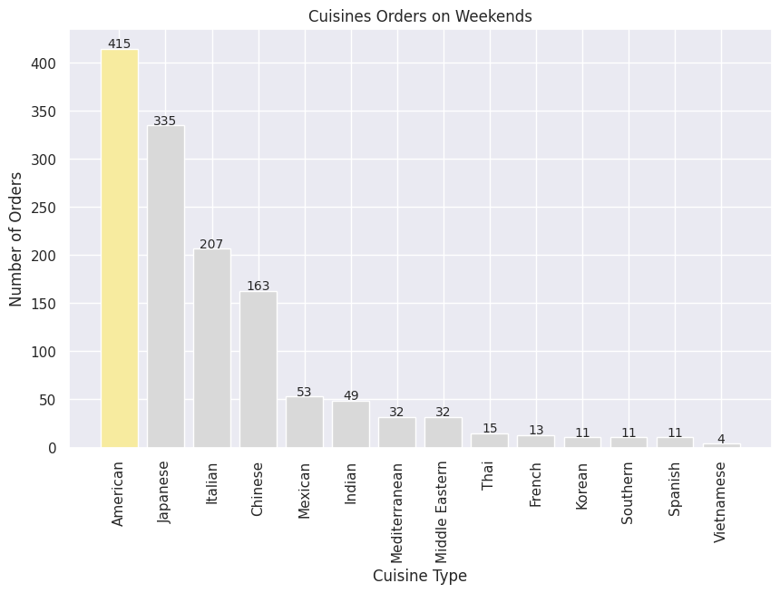

```python
# Filter the data frame to only include orders placed on weekends
weekend_orders = df[df['day_of_the_week'] == 'Weekend']

# Group the orders by cuisine type and count the number of orders for each cuisine
cuisine_orders = weekend_orders.groupby('cuisine_type')['order_id'].count()

# Sort the cuisines in descending order of number of orders
top_cuisines = cuisine_orders.sort_values(ascending=False)

# Get the index of the top cuisine (the most popular one)
top_cuisine_index = top_cuisines.index[0]

# Set the color of the bars to grey by default
colors = ['#d9d9d9'] * len(top_cuisines)

# Set the color of the top cuisine to a different color
colors[top_cuisines.index.get_loc(top_cuisine_index)] = '#f7eb9f'

# Plot the cuisines with the colors
plt.figure(figsize=(10,6))
plt.bar(top_cuisines.index, top_cuisines.values, color=colors)

# Add labels, title, and value labels as before
plt.xlabel('Cuisine Type')
plt.xticks(rotation=90)
plt.ylabel('Number of Orders')
plt.title('Cuisines Orders on Weekends')

for i, v in enumerate(top_cuisines.values):
    plt.text(i, v+1, str(v), ha='center', fontsize=10)

plt.show()
```

#### Observations:

The most popular cuisine on weekends is American cuisine. It received 415 orders.

### **Question 9**: What percentage of the orders cost more than 20 dollars? [2 marks]

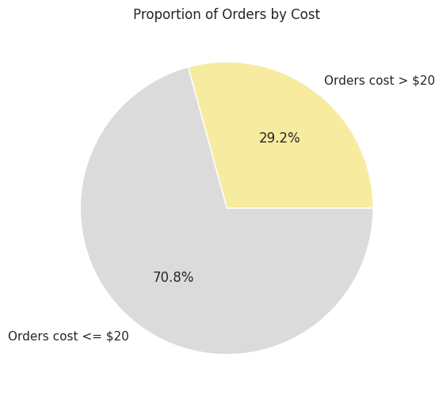

```python
# Filter the orders that cost more than 20 dollars
expensive_orders = df[df['cost_of_the_order'] > 20]

# Calculate the proportion of expensive orders
num_expensive_orders = len(expensive_orders)
num_affordable_orders = len(df) - num_expensive_orders
proportions = [num_expensive_orders, num_affordable_orders]

# Plot the proportions as a pie chart
plt.figure(figsize=(6, 6))
plt.pie(proportions, labels=['Orders cost > $20', 'Orders cost <= $20'], colors=['#f7eb9f', '#dbdbdb'], autopct='%1.1f%%')
plt.title('Proportion of Orders by Cost')
plt.show()
```

#### Observations:

29.2% of orders cost more than $20.

### **Question 10**: What is the mean order delivery time? [1 mark]

```python
# Calculate the mean order delivery time
mean_delivery_time = df['delivery_time'].mean()

# Print the result
print("The mean order delivery time is {:.2f} minutes.".format(mean_delivery_time))
```

```
The mean order delivery time is 24.16 minutes.
```

#### Observations:

The mean of order delivery time is 24.16 minutes.

### **Question 11:** The company has decided to give 20% discount vouchers to the top 3 most frequent customers. Find the IDs of these customers and the number of orders they placed. [1 mark]

```python
# Group the orders by customer ID and count the number of orders for each customer
customer_orders = df.groupby('customer_id')['order_id'].count()

# Sort the customers in descending order of number of orders and get the top 3
top_customers = customer_orders.sort_values(ascending=False).head(3)

# Print the IDs of the top 3 customers and the number of orders they placed
for customer_id, order_count in top_customers.items():
    print("Customer ID {} placed {} orders.".format(customer_id, order_count))
```

```
Customer ID 52832 placed 13 orders.
Customer ID 47440 placed 10 orders.
Customer ID 83287 placed 9 orders.
```

#### Observations:

The top 3 most frequent customers and the number of orders they placed:  
Customer ID 52832 placed 13 orders.  
Customer ID 47440 placed 10 orders.  
Customer ID 83287 placed 9 orders.

### **Question 12**: Perform a multivariate analysis to explore relationships between the important variables in the dataset. (It is a good idea to explore relations between numerical variables as well as relations between numerical and categorical variables) [10 marks]

**Correlation among variables**

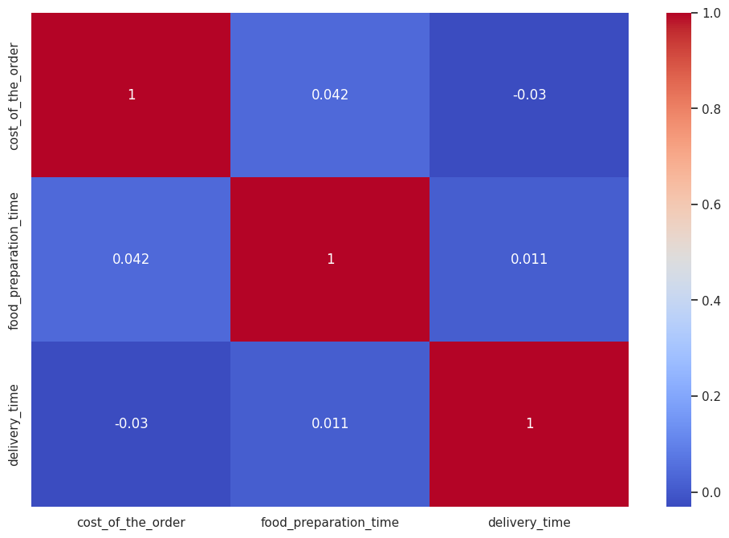

```python
# select the numerical variables
numerical_vars = ['cost_of_the_order', 'food_preparation_time', 'delivery_time']

# calculate the correlation matrix
corr_matrix = df[numerical_vars].corr()

# visualize the correlation matrix using a heatmap
sns.heatmap(corr_matrix, annot=True, cmap='coolwarm')
plt.show()
```

- The correlation coefficient between 'cost_of_the_order' and 'food_preparation_time' is 0.042. Since the value is close to 0, we can conclude that there is a **weak positive correlation** between these two variables. This means that **as the cost of the order increases, the food preparation time tends to increase slightly as well, but the relationship is not very strong**.
- The correlation coefficient between 'cost_of_the_order' and 'delivery_time' is -0.03. Since the value is close to 0, we can conclude that there is a **weak negative correlation** between these two variables. This means that as **the cost of the order increases, the delivery time tends to decrease slightly, but again, the relationship is not very strong**.
- The correlation coefficient between 'food_preparation_time' and 'delivery_time' is 0.011. Since the value is very close to 0, we can conclude that there is **no significant correlation** between these two variables. This means that **the food preparation time and the delivery time do not tend to be related to each other**.
- Overall, the heatmap suggests that there is no strong correlation between the numerical variables in the dataset, and that they may be relatively independent of each other. However, it's important to note that **correlation does not imply causation**, so we cannot make any causal inferences from these results alone.

**Cost of order VS Day of the week**

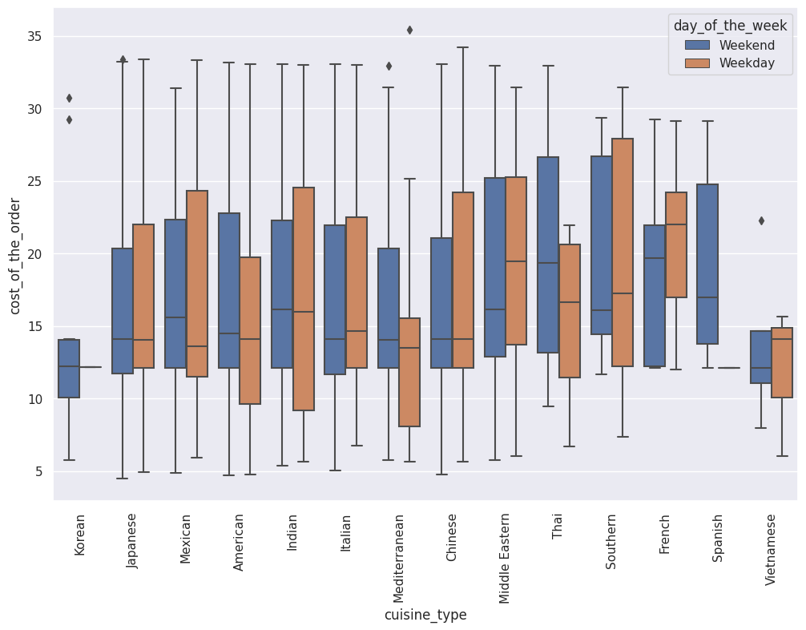

```python
sns.boxplot(x='cuisine_type', y='cost_of_the_order', hue='day_of_the_week', data=df)
sns.set_style('whitegrid')
sns.set(rc={'figure.figsize':(12,8)})
plt.xticks(rotation=90)
plt.show()
```

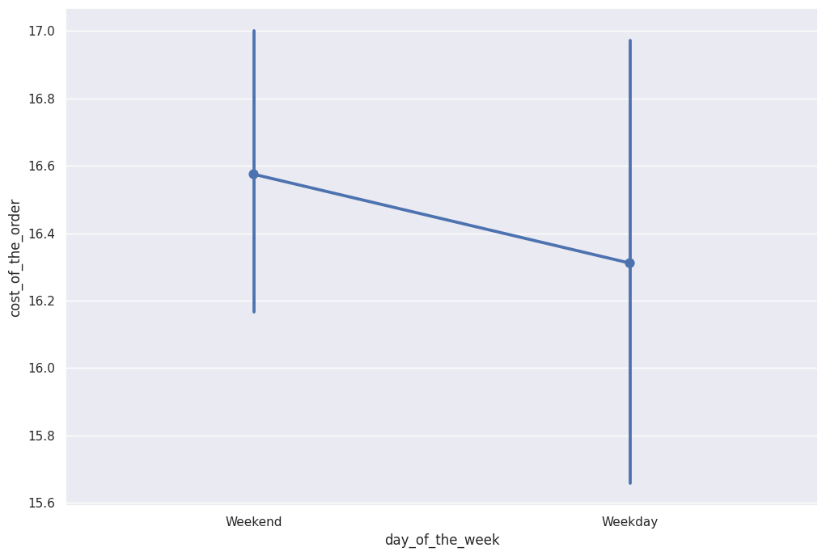

```python
sns.pointplot(x='day_of_the_week', y='cost_of_the_order', data=df)
```

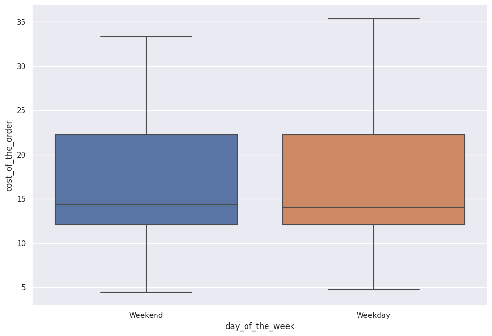

```python
sns.boxplot(x='day_of_the_week', y='cost_of_the_order', data=df)
sns.set_style('whitegrid')
sns.set(rc={'figure.figsize':(8,6)})
plt.show()
```

- The average cost of the orders on weekdays is approximately 16.31 dollars.
- The average cost of the orders on weekends is slightly higher, at approximately 16.57 dollars.

From these results, we can infer that there is a **small difference** in the average order cost between weekdays and weekends. However, the difference is not substantial, so it might not have a significant impact on the overall trends or patterns in the dataset.

**Cost of order VS Cuisine Type**

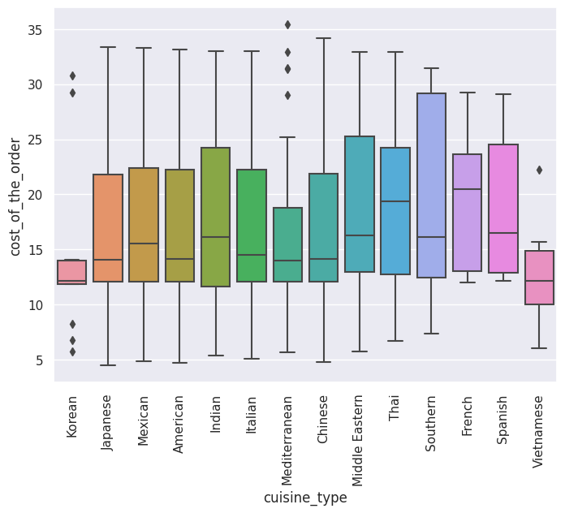

```python
sns.boxplot(x='cuisine_type', y='cost_of_the_order', data=df)
sns.set_style('whitegrid')
sns.set(rc={'figure.figsize':(12,8)})
plt.xticks(rotation=90)
plt.show()
```

The minimum cost of an order across all cuisine types falls within the range of 4-7 dollars, except for French and Spanish cuisine, where the minimum order cost is higher than 10 dollars.

While French cuisine may be slightly more expensive than other cuisines at the minimum order cost level, when we examine its 25th percentile, median, and 75th percentile, it falls within the same range as other cuisines. Additionally, the maximum cost of French cuisine is not the most expensive among all cuisines if we exclude outliers. In fact, Chinese cuisine has the highest maximum cost among all cuisines, excluding outliers.

We will look deeper into the outliers below:

```python
# Define a function to find the outliers
def find_outliers(data, column, multiplier=1.5):
    Q1 = data[column].quantile(0.25)
    Q3 = data[column].quantile(0.75)
    IQR = Q3 - Q1
    lower_bound = Q1 - (multiplier * IQR)
    upper_bound = Q3 + (multiplier * IQR)

    return data[(data[column] < lower_bound) | (data[column] > upper_bound)]

# Filter the data for each cuisine type
korean_df = df[df['cuisine_type'] == 'Korean']
mediterranean_df = df[df['cuisine_type'] == 'Mediterranean']
vietnamese_df = df[df['cuisine_type'] == 'Vietnamese']

# Find and print the outlier values for each cuisine type
korean_outliers = find_outliers(korean_df, 'cost_of_the_order')
mediterranean_outliers = find_outliers(mediterranean_df, 'cost_of_the_order')
vietnamese_outliers = find_outliers(vietnamese_df, 'cost_of_the_order')

print("Korean Cuisine Outliers:\n", korean_outliers)
print("\nMediterranean Cuisine Outliers:\n", mediterranean_outliers)
print("\nVietnamese Cuisine Outliers:\n", vietnamese_outliers)
```

```
Korean Cuisine Outliers:
       order_id  customer_id restaurant_name cuisine_type  cost_of_the_order  \
0      1477147       337525         Hangawi       Korean              30.75
301    1476856        59674        Woorijip       Korean               8.25
464    1477600       347263         Hangawi       Korean               6.74
653    1478363       138024    Cho Dang Gol       Korean              29.25
1550   1477307       141732    Cho Dang Gol       Korean               5.77

     day_of_the_week     rating  food_preparation_time  delivery_time
0            Weekend  Not given                     25             20
301          Weekend          3                     26             26
464          Weekend  Not given                     21             22
653          Weekend          4                     23             21
1550         Weekend          5                     21             17

Mediterranean Cuisine Outliers:
       order_id  customer_id    restaurant_name   cuisine_type  \
524    1476934       126134  Jack's Wife Freda  Mediterranean
573    1477814        62359              Pylos  Mediterranean
858    1476968        99621  Jack's Wife Freda  Mediterranean
1132   1477961       167738  Jack's Wife Freda  Mediterranean
1148   1478044       354719  Jack's Wife Freda  Mediterranean

      cost_of_the_order day_of_the_week     rating  food_preparation_time  \
524               32.93         Weekend          3                     21
573               35.41         Weekday          4                     21
858               29.05         Weekend          5                     35
1132              31.43         Weekend          5                     34
1148              31.38         Weekend  Not given                     28

      delivery_time
524              16
573              29
858              28
1132             20
1148             18

Vietnamese Cuisine Outliers:
      order_id  customer_id restaurant_name cuisine_type  cost_of_the_order  \
746   1477189        54630      V-Nam Cafe   Vietnamese              22.26

    day_of_the_week rating  food_preparation_time  delivery_time
746         Weekend      5                     33             26
```

To determine if outliers are significantly impacting our analysis:

```python
print("With Outliers:")
print(df['cost_of_the_order'].describe())

print("\nWithout Outliers:")
df_without_outliers = df[~df.index.isin(korean_outliers.index)]
df_without_outliers = df_without_outliers[~df_without_outliers.index.isin(mediterranean_outliers.index)]
df_without_outliers = df_without_outliers[~df_without_outliers.index.isin(vietnamese_outliers.index)]
print(df_without_outliers['cost_of_the_order'].describe())
```

```
With Outliers:
count    1898.000000
mean       16.498851
std         7.483812
min         4.470000
25%        12.080000
50%        14.140000
75%        22.297500
max        35.410000
Name: cost_of_the_order, dtype: float64

Without Outliers:
count    1887.000000
mean       16.455538
std         7.437822
min         4.470000
25%        12.080000
50%        14.120000
75%        22.260000
max        34.190000
Name: cost_of_the_order, dtype: float64
```

Based on the summary statistics above, the difference between the dataset with outliers and the dataset without outliers is **minimal**. The mean and standard deviation have only slightly changed, and the quartiles are mostly consistent. It seems that the outliers will not significantly affect our analysis.

**Cuisine vs Food Preparation time**

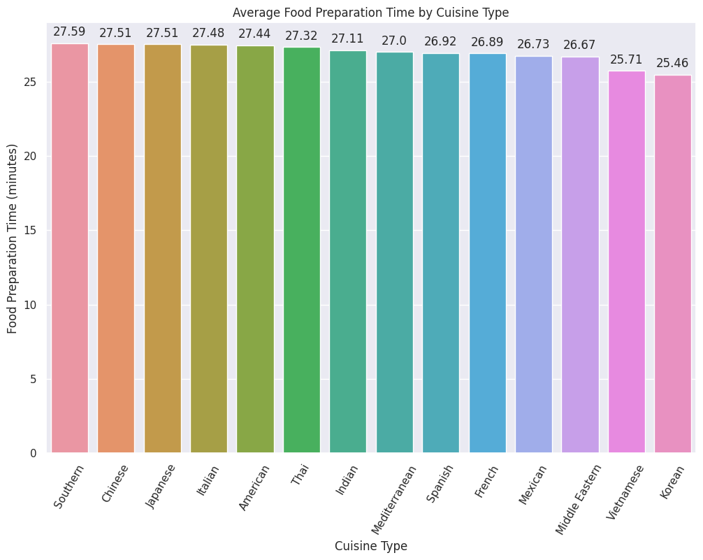

```python
# Calculate the mean food preparation time for each cuisine type
prep_time_by_cuisine = df.groupby('cuisine_type')['food_preparation_time'].mean().reset_index()

# Sort the values in descending order of mean food preparation time
prep_time_by_cuisine = prep_time_by_cuisine.sort_values(by='food_preparation_time', ascending=False)

# Plot the barplot with the ordered cuisine types
plt.figure(figsize=(12, 8))
ax = sns.barplot(data=prep_time_by_cuisine, x='cuisine_type', y='food_preparation_time', errorbar=None)
plt.xlabel('Cuisine Type')
plt.xticks(rotation = 60)
plt.ylabel('Food Preparation Time (minutes)')
plt.title('Average Food Preparation Time by Cuisine Type')

# Add values on top of the bars
for i, v in enumerate(prep_time_by_cuisine['food_preparation_time']):
    ax.text(i, v+0.5, str(round(v, 2)), ha='center')

plt.show()
```

- Based on the barplot of the average food preparation time by cuisine type, it appears that there is not a significant difference in the food preparation times across the different cuisine types.
- The average food preparation time for each cuisine type is relatively similar, with a difference of around 2 minutes between the cuisine types with the longest and shortest average food preparation times.
- This suggests that the cuisine type may not be a significant factor in determining the food preparation time for orders in this dataset.
- However, it is important to note that other factors, such as restaurant location, order volume, and time of day, may also play a role in determining food preparation times, and further analysis may be required to fully understand the relationship between these variables.

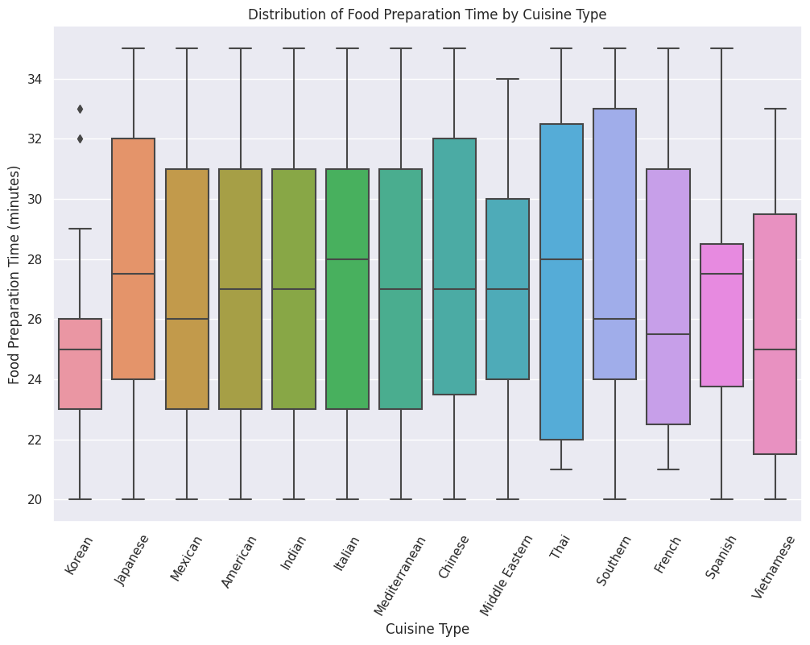

```python
plt.figure(figsize=(12, 8))
sns.boxplot(data=df, x='cuisine_type', y='food_preparation_time')
plt.xlabel('Cuisine Type')
plt.xticks(rotation = 60)
plt.ylabel('Food Preparation Time (minutes)')
plt.title('Distribution of Food Preparation Time by Cuisine Type')
plt.show()
```

- Overall, the boxplot suggests that the food preparation times for the different cuisine types are relatively similar, with most falling within a narrow range of 26-28 minutes, and that there is not a significant difference in the food preparation times across the different cuisine types.
- There are 2 outliers in Korean cuisine. These outliers could represent extreme values for food preparation time, which could be caused by various factors, such as high order volume or unique cooking techniques. Further investigation may be needed to determine the cause of these outliers and whether they should be excluded from analysis.

**Day of the Week vs Delivery time**

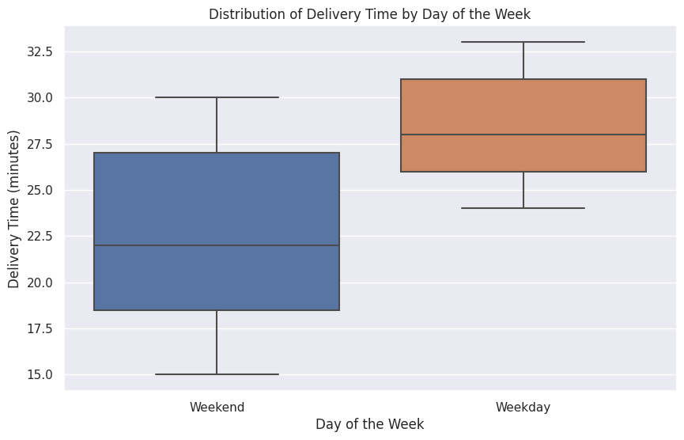

```python
# Plot the boxplot of delivery time by day of the week
plt.figure(figsize=(10, 6))
sns.boxplot(data=df, x='day_of_the_week', y='delivery_time')
plt.xlabel('Day of the Week')
plt.ylabel('Delivery Time (minutes)')
plt.title('Distribution of Delivery Time by Day of the Week')
plt.show()
```

- Overall, the boxplot suggests that the delivery time is shorter on weekends than on weekdays. However, further analysis may be required to understand the factors that affect delivery time, such as the order volume, restaurant location, numbers of delivery drivers and time of day.

```python
df.groupby(['restaurant_name'])['cost_of_the_order'].sum().sort_values(ascending = False).head(14)
```

```
restaurant_name
Shake Shack                      3579.53
The Meatball Shop                2145.21
Blue Ribbon Sushi                1903.95
Blue Ribbon Fried Chicken        1662.29
Parm                             1112.76
RedFarm Broadway                  965.13
RedFarm Hudson                    921.21
TAO                               834.50
Han Dynasty                       755.29
Blue Ribbon Sushi Bar & Grill     666.62
Rubirosa                          660.45
Sushi of Gari 46                  640.87
Nobu Next Door                    623.67
Five Guys Burgers and Fries       506.47
Name: cost_of_the_order, dtype: float64
```

**Rating vs Delivery time**

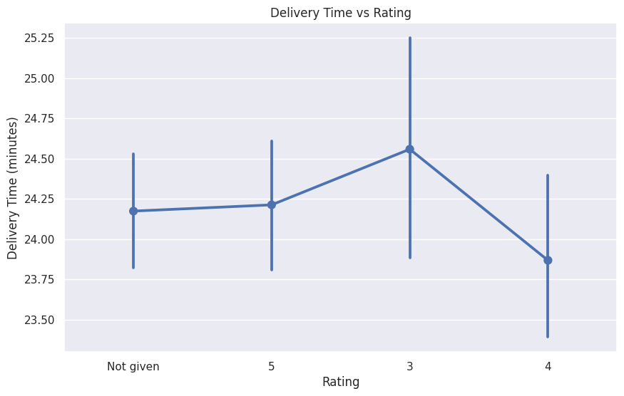

```python
plt.figure(figsize=(10,6))
sns.pointplot(data=df, x='rating', y='delivery_time')
plt.xlabel('Rating')
plt.ylabel('Delivery Time (minutes)')
plt.title('Delivery Time vs Rating')
plt.show()
```

- Based on the pointplot, it appears that there is little to no relationship between the rating given by customers and the delivery time of their orders. The mean delivery time for each rating category are around 24 minutes and do not show a significant difference between different rating scores.
- The confidence intervals (CI) vertical line for the mean delivery time for the 3- and 4-star rating categories are longer than those for the 'Not given' and 5-star categories, it suggests that there is more variability in the delivery time for the 3- and 4-star ratings. This means that the delivery time for orders with 3- and 4-star ratings are more spread out and less consistent than those for orders with 'Not given' and 5-star ratings.

**Rating vs Food preparation**

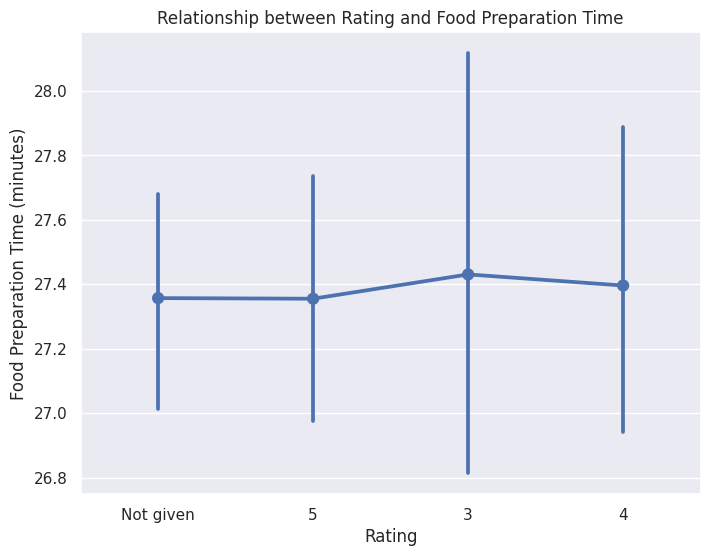

```python
plt.figure(figsize=(8,6))
sns.pointplot(data=df, x='rating', y='food_preparation_time')
plt.xlabel('Rating')
plt.ylabel('Food Preparation Time (minutes)')
plt.title('Relationship between Rating and Food Preparation Time')
plt.show()
```

- Based on the pointplot, it appears that there is little to no relationship between the rating given by customers and the food preparation time of their orders. The mean food preparation time for each rating category are around 27 minutes and do not show a significant difference between different rating scores.
- The confidence intervals (CI) vertical line for the mean food preperation time for the 3-star rating categories are longer than other categories, it suggests that there is more variability in the food preperation time for the 3-star ratings. This means that the food preperation time for orders with 3-star ratings are more spread out and less consistent than those orders with other ratings.

**Rating vs Cost of the order**

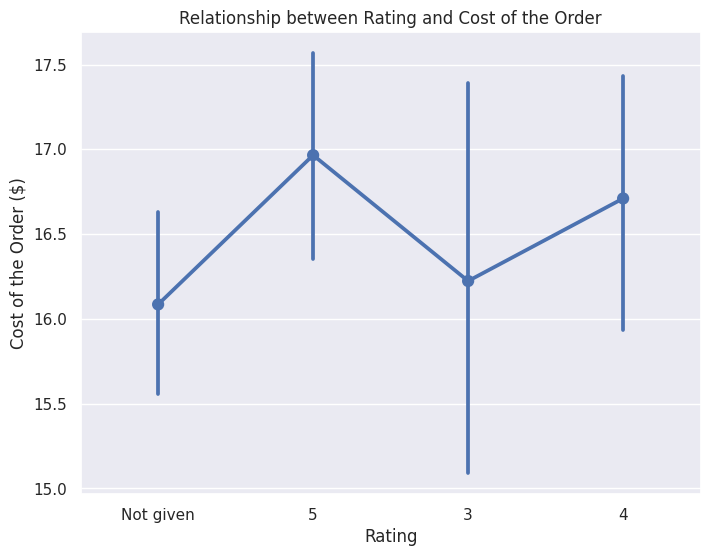

```python
plt.figure(figsize=(8,6))
sns.pointplot(data=df, x='rating', y='cost_of_the_order')
plt.xlabel('Rating')
plt.ylabel('Cost of the Order ($)')
plt.title('Relationship between Rating and Cost of the Order')
plt.show()
```

- Based on the pointplot, it appears that there is little to no relationship between the rating given by customers and the cost of their orders. The mean cost of the order for each rating category are around $16 - $17 and do not show a significant difference between different rating scores.
- The confidence intervals (CI) vertical line for the mean cost of the order for the 3-star rating categories are longer than other categories, This could suggest that there is more variability in the cost of orders that receive a 3-star rating, as compared to orders with other ratings. It appears that the cost of the order for 3-star ratings is more spread out and less consistent than for other rating categories.

### **Question 13:** The company wants to provide a promotional offer in the advertisement of the restaurants. The condition to get the offer is that the restaurants must have a rating count of more than 50 and the average rating should be greater than 4. Find the restaurants fulfilling the criteria to get the promotional offer. [3 marks]

```python
# Filter out rows with "Not given" in "rating" column
df_with_ratings = df.loc[df['rating'] != 'Not given'].copy()

# Convert "rating" column to numeric
df_with_ratings['rating'] = pd.to_numeric(df_with_ratings['rating'])

# Group by restaurant name and count ratings greater than 4
restaurant_ratings = df_with_ratings.groupby('restaurant_name')['rating'].agg(['count', 'mean']).reset_index()
promo_restaurants = restaurant_ratings[(restaurant_ratings['count'] > 50) & (restaurant_ratings['mean'] > 4)]

# Print the restaurants fulfilling the criteria for the promotional offer
print(promo_restaurants)
```

```
               restaurant_name  count      mean
16   Blue Ribbon Fried Chicken     64  4.328125
17           Blue Ribbon Sushi     73  4.219178
117                Shake Shack    133  4.278195
132          The Meatball Shop     84  4.511905
```

#### Observations:

There are **4** restaurants which can fulfill the criteria, including 'Blue Ribbon Fried Chicken', 'Blue Ribbon Sushi', 'Shake Shack' as well as 'The Meatball Shop'.

### **Question 14:** The company charges the restaurant 25% on the orders having cost greater than 20 dollars and 15% on the orders having cost greater than 5 dollars. Find the net revenue generated by the company across all orders. [3 marks]

```python
# Calculate commission earned for each order
df['commission'] = 0
df.loc[df['cost_of_the_order'] > 20, 'commission'] = df['cost_of_the_order'] * 0.25
df.loc[(df['cost_of_the_order'] > 5) & (df['cost_of_the_order'] <= 20), 'commission'] = df['cost_of_the_order'] * 0.15

# Calculate net revenue
net_revenue = df['commission'].sum()

print('Net revenue generated by the company: $', round(net_revenue, 2))
```

```
Net revenue generated by the company: $ 6166.3
```

#### Observations:

The net revenue generated by the company is **$ 6166.3**

### **Question 15:** The company wants to analyze the total time required to deliver the food. What percentage of orders take more than 60 minutes to get delivered from the time the order is placed? (The food has to be prepared and then delivered.) [2 marks]

```python
# Calculate the total time required to deliver the food for each order
df['total_delivery_time'] = df['food_preparation_time'] + df['delivery_time']

# Calculate the percentage of orders that take more than 60 minutes to get delivered
num_orders_greater_than_60 = df[df['total_delivery_time'] > 60]['total_delivery_time'].count()
total_orders = len(df)
percentage_greater_than_60 = (num_orders_greater_than_60 / total_orders) * 100

print(f"{percentage_greater_than_60:.2f}% of orders take more than 60 minutes to get delivered.")
```

```
10.54% of orders take more than 60 minutes to get delivered.
```

#### Observations:

**10.54%** of orders take more than 60 minutes to get delivered.

### **Question 16:** The company wants to analyze the delivery time of the orders on weekdays and weekends. How does the mean delivery time vary during weekdays and weekends? [2 marks]

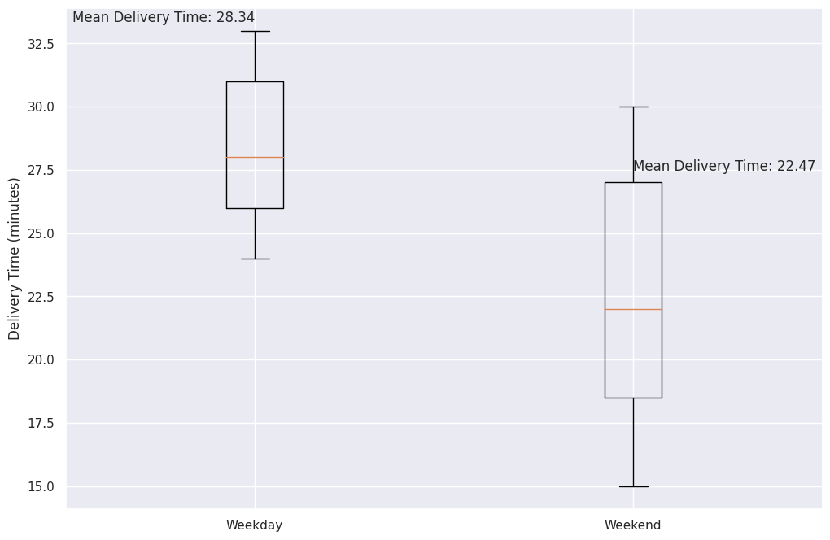

```python
# Filter data for weekdays and weekends
weekday_data = df[df['day_of_the_week'] == 'Weekday']
weekend_data = df[df['day_of_the_week'] == 'Weekend']

# Plot boxplots for delivery time for weekdays and weekends
plt.boxplot([weekday_data['delivery_time'], weekend_data['delivery_time']])
plt.xticks([1, 2], ['Weekday', 'Weekend'])
plt.ylabel('Delivery Time (minutes)')

# Add mean value label for weekday and weekend boxplots
weekday_mean = round(weekday_data['delivery_time'].mean(), 2)
weekend_mean = round(weekend_data['delivery_time'].mean(), 2)
plt.text(1, weekday_mean+5, f"Mean Delivery Time: {weekday_mean:.2f}", ha='right', fontsize=12)
plt.text(2, weekend_mean+5, f"Mean Delivery Time: {weekend_mean:.2f}", ha='left', fontsize=12)

# Show the plot
plt.show()
```

#### Observations:

The mean delivery time during weekdays is **28.34** minutes, while it is **22.47** minutes during weekends, indicating a difference of approximately **5.87 minutes**.

### Conclusion and Recommendations

### **Question 17:** What are your conclusions from the analysis? What recommendations would you like to share to help improve the business? (You can use cuisine type and feedback ratings to drive your business recommendations.) [6 marks]

### Conclusions:

- The dataset contains information on 1898 orders that were made by 1200 different customers, across 178 different restaurants.
- Weekends are the most popular time for orders, with more than twice as many orders as weekdays.
- American cuisine is the most popular, followed by Japanese cuisine.
- Approximately 89% of orders are completed, including food preparation and delivery, within 60 minutes.
- About 29.2% of orders cost over $20, indicating that the price of food is reasonable.
- The delivery time on weekends and weekdays differs only by five minutes, indicating that there are enough human resources to handle the increased orders and busy environment during weekends.
- It appears that there is no strong relationship between customers' ratings and food preparation time, delivery time, or cost of orders.

### Recommendations:

- A recommendation for obtaining a more comprehensive understanding of customer satisfaction would be to gather data on orders for all days of the week, including holidays, and during lunch, tea, and dinner hours to analyze order volume. Additionally, collecting more information such as restaurant location and the numbers of delivery person/driver would provide more insights into the data and help to better understand the relationship between factors such as delivery time, food preparation time, and customers' ratings.
- Without additional information or context, it is difficult to definitively determine the exact meaning of each rating. However, generally speaking, a rating of 3 out of 5 is typically considered average or satisfactory, while a rating of 4 or 5 out of 5 is generally considered good or very good. It is unlikely that a rating of 5 out of 5 would represent a level of extreme dissatisfaction. Additionally, since we do not have any values for 0-2 stars in the dataset, we cannot determine whether the 3-star ratings correspond to 'poor' or 'moderate' or any other description. It is always best to consult with the department that collected the data to obtain a more accurate and detailed understanding of the rating system used.
- In order to improve our rating system and reduce the number of "Not given" ratings, we can explore ways to gather more feedback from customers. To achieve this, we can switch to a 5-star rating system, where 1 star represents unsatisfactory and 5 stars represent very satisfactory. Additionally, we can add a comment section to the questionnaire to encourage customers to leave more detailed feedback. As an incentive for customers to provide feedback, we can offer random discounts for their next purchase. Also, we need a more detailed rating system data, to obtain the feedback from food quality to cost of the food, so that we can gain a better understanding of the data.
- As American cuisine is the most popular cuisine among our customers, we can consider inviting more American restaurants to join our business. To further promote American cuisine and attract food enthusiasts, we can also organize American food festivals.